# United States Solar Energy Consumption

# Introduction

This script explores trends in monthly United States solar energy consumption. Data was collected by the U.S. Energy Information Administration (https://www.eia.gov/).

# Setup

Define Functions:

```r
#Function to convert a PERIOD_ID (YYYYMM) to a date (MM/01/YYYY)
period_to_date <- function(col){
  DATE <- as.Date(paste(as.numeric(col) %% 100, 1,
                                  round(as.numeric(col) %/% 100,0),
                                  sep = "/"), "%m/%d/%Y")
  return(DATE)
}

#Function to pull data using API call
API_request <- function(API_call, API_key){
  res = GET(sub('YOUR_API_KEY_HERE', API_key, API_call))
  data = fromJSON(rawToChar(res$content))
  consumption_data <- as.data.frame(data$series$data)
  consumption_data <- consumption_data %>%
    rename(PERIOD_ID = X1,
      TRILLION_BTU = X2)
  consumption_data$DATE <- period_to_date(consumption_data$PERIOD_ID)
  return(consumption_data)
}

#Function to run naive model
naive_model <- function(ts_train, ts_test){
  require(forecast)
  model <- naive(ts_train, level=c(80,95), h=12)
  plot(model, xlab="Date", ylab="Trillion Btu")
  lines(ts_test, col='red')
  data_eval <- data.frame(actual_data=as.matrix(ts_test),
                          date=as.Date(as.yearmon(time(ts_test))))
  data_eval <- cbind(data_eval, predicted = model$mean)
  return(list(aicc = model$aicc, model = model, data_eval = data_eval))
}

#Function to run ARIMA model without external regressors
arima_model <- function(ts_train, ts_test){
  require(forecast)
  model <- auto.arima(ts_train,
                          stepwise = FALSE,
                          approximation = FALSE,
                          seasonal = FALSE,
                          ic = 'aicc')
  forecast_data <- forecast(model, level=c(80,95), h= 12)
  plot(forecast_data, xlab="Date", ylab="Trillion Btu")
  lines(ts_test, col='red')
  data_eval <- data.frame(actual_data=as.matrix(ts_test),
                          date=as.Date(as.yearmon(time(ts_test))))
  data_eval <- cbind(data_eval, predicted = forecast_data$mean)
  return(list(aicc = model$aicc, model = model, data_eval = data_eval))
}

#Function to run ARIMA model with Fourier component of different external regressors and pull out best performing forecast by aicc
best_fourier <- function(ts_train, ts_test){
  require(forecast)
  models <- lapply(seq(1,6), function(j){
    try(auto.arima(ts_train,
                   xreg = fourier(ts_train, K=j),
                   seasonal = FALSE,
                   stepwise = FALSE,
                   approximation = FALSE,
                   ic = 'aicc'))
  })
  best_forecast <- which.min(sapply(models, function(x){x[['aicc']]}))
  forecast_data <- forecast(models[[best_forecast]], level=c(80,95),
                                xreg = fourier(ts_train, K=best_forecast,
                                               h= 12))
  plot(forecast_data, xlab="Date", ylab="Trillion Btu")
  lines(ts_test, col='red')
  data_eval <- data.frame(actual_data=as.matrix(ts_test),
                          date=as.Date(as.yearmon(time(ts_test))))
  data_eval <- cbind(data_eval, predicted = forecast_data$mean)
  return(list(aicc = models[[best_forecast]]$aicc,
              model = models[[best_forecast]], k= best_forecast,
              data_eval = data_eval))
}

# Function to run ETS model
ets_model <- function(ts_train, ts_test){
  require(forecast)
  model <- ets(ts_train)
  forecast_data <- forecast(model, level=c(80,95), h= 12)
  plot(forecast_data, xlab="Date", ylab="Trillion Btu")
  lines(ts_test, col='red')
  data_eval <- data.frame(actual_data=as.matrix(ts_test),
                          date=as.Date(as.yearmon(time(ts_test))))
  data_eval <- cbind(data_eval, predicted = forecast_data$mean)
  return(list(aicc = model$aicc, model = model, data_eval = data_eval))
}

#Function to get model metrics
get_metrics <- function(data_eval){
  model_MAPE <- mape(data_eval$actual, data_eval$predicted)
  model_RMSE <- round(rmse(data_eval$actual, data_eval$predicted), 2)
  model_MAE <- round(mae(data_eval$actual, data_eval$predicted), 2)
  model_MASE <- round(mase(data_eval$actual, data_eval$predicted), 2)
  model_bias <- round(bias(data_eval$actual, data_eval$predicted),2)
  metrics <- list(model_MAPE, model_RMSE, model_MASE, model_MAE, model_bias)
  names(metrics) <- c('MAPE', 'RMSE', 'MAE', 'MASE', 'Bias')
  metrics <- as.data.frame(metrics)
  metrics$MAPE <- percent(metrics$MAPE, accuracy = 0.01)
  return(metrics)
}

#Create summary table of all metrics results
metrics_summary <- function(dfNames) {
  do.call(rbind, lapply(dfNames, function(x) {
    cbind(Model = strsplit(x,'_')[[1]][1], get(x))
  }))
}
```

Pull the data using the API request.

```r
api_key = 'b7369a57166eee9b3612e8774f172306'
solar <- API_request("http://api.eia.gov/series/?api_key=YOUR_API_KEY_HERE&series_id=TOTAL.SOTCBUS.M", api_key)
```

# Data Exploration

Convert consumption data to numeric, impute missing data with 0, and slice the data to remove time points before the first occurrence of solar energy consumption (where TRILLION_BTU > 0).

```r
solar$TRILLION_BTU <- as.numeric(solar$TRILLION_BTU)
solar$TRILLION_BTU[is.na(solar$TRILLION_BTU)] <- 0
solar <- solar[order(solar$DATE),]
first_value <- which.max(solar$TRILLION_BTU > 0)
solar <- solar %>% slice(first_value:n())
```

View the time series plot for solar energy consumption.

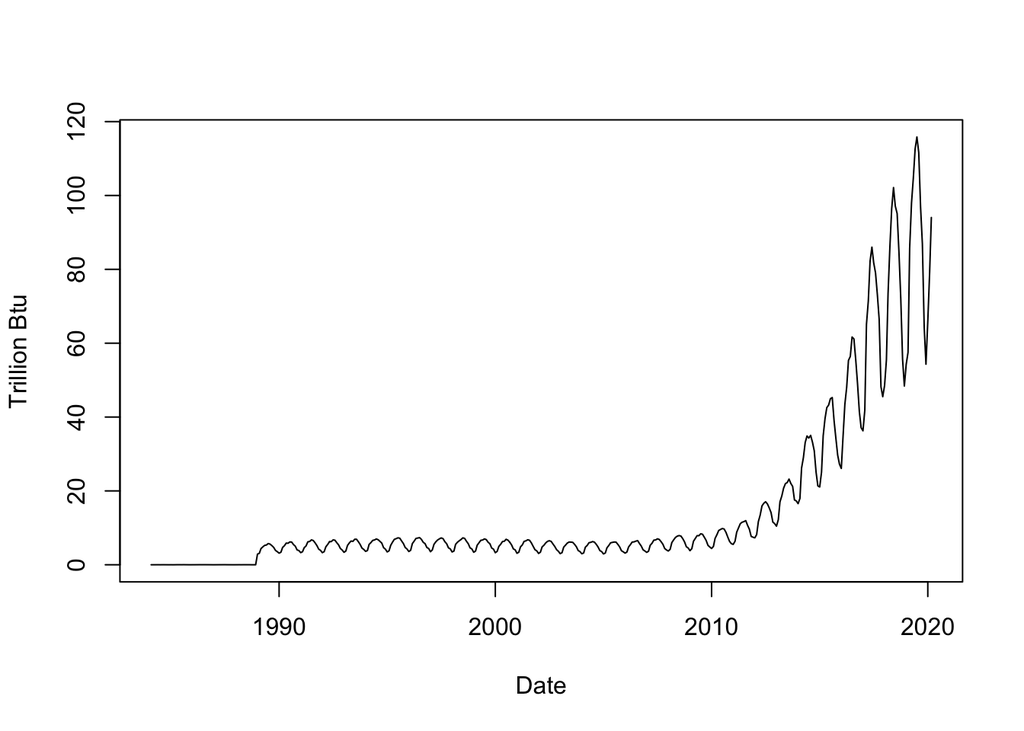

```r
plot(solar$DATE, solar$TRILLION_BTU, type = 'l', xlab="Date", ylab="Trillion Btu")
```

Split data into train/test sets - leaving 1 year of data for performance evaluation.

```r
#split where there are 12 remaining months left
cut_loc <- which(solar$DATE > seq(max(solar$DATE), length=2, by="-1 years")[2])
train_data <- solar[-cut_loc,]
test_data <- solar[cut_loc,]
```

Create time series data train/test sets.

```r
start_year_train = as.numeric(format(as.Date(min(train_data$DATE), format="%d/%m/%Y"),"%Y"))
start_month_train = as.numeric(format(as.Date(min(train_data$DATE), format="%d/%m/%Y"),"%m"))
ts_train <- ts(train_data$TRILLION_BTU,
               start = c(start_year_train, start_month_train), frequency = 12)

start_year_test = as.numeric(format(as.Date(min(test_data$DATE), format="%d/%m/%Y"),"%Y"))
start_month_test = as.numeric(format(as.Date(min(test_data$DATE), format="%d/%m/%Y"),"%m"))
ts_test <- ts(test_data$TRILLION_BTU,start = c(start_year_test, start_month_test), frequency=12)
```

Explore the components of the time series train data.

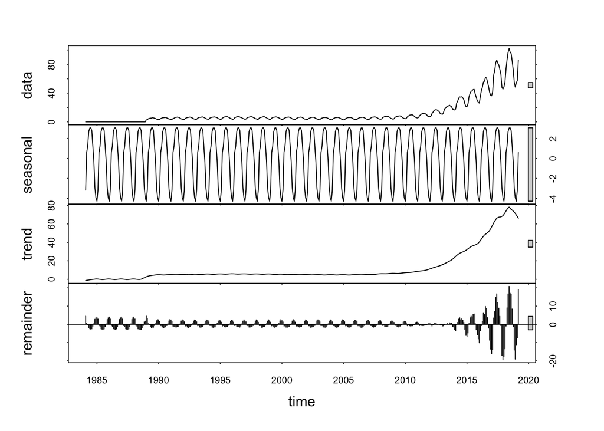

```r
fit <- stl(ts_train, s.window="period")
plot(fit)
```

In the plots above, there is a similar seasonal trend throughout the entire time series. The trend in solar energy consumption begins increasing slowly in the late 1980’s and then more rapidly increases beginning around 2012. The more rapid increase in 2012 may be due to policy changes in the United States including Production Tax Credits and Investment Tax Credits for solar energy and the American Reinvestment and Recovery Act of 2009.

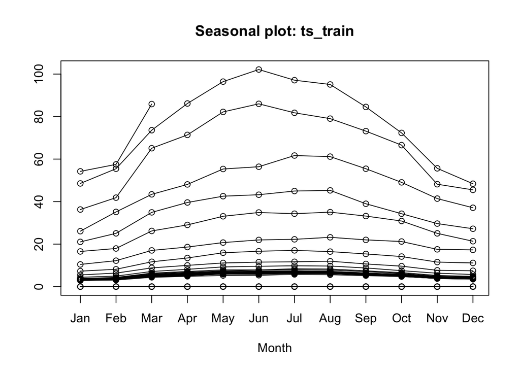

```r
# additional plots
seasonplot(ts_train)
```

```r
naive_results <- naive_model(ts_train, ts_test)
```

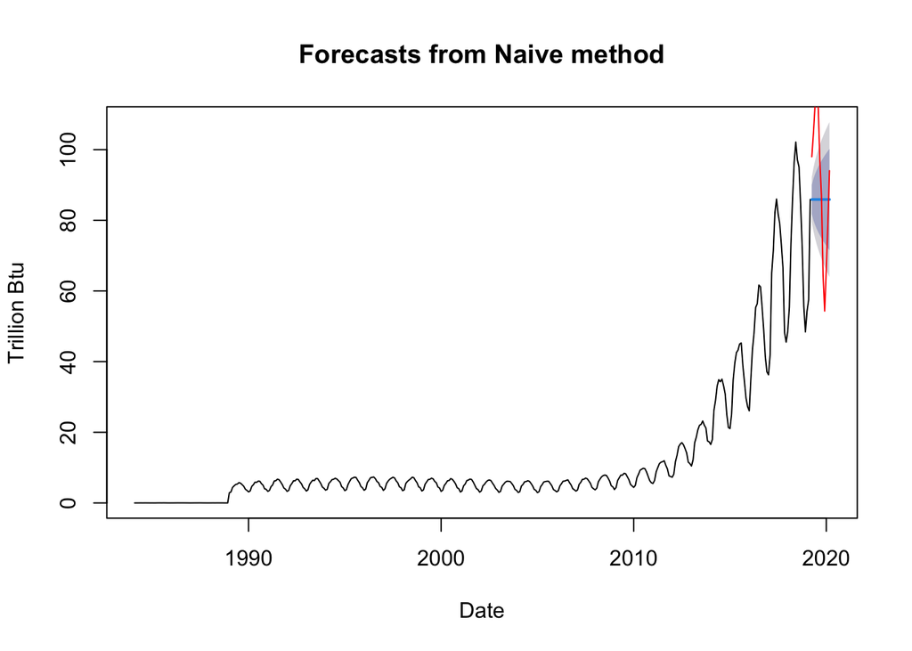

In addition to viewing the forecast plot, I will also quantify the model performance using several model metrics, including mean absolute percentage error (MAPE), root mean squared error (RMSE), mean absolute error (MAE), mean absolute scaled error (MASE) and bias.

```r
naive_metrics <- get_metrics(naive_results$data_eval)
kable(as.data.frame(naive_metrics) %>% select_all, caption = "Naive Forecast Metrics") %>% kable_styling(full_width = F, bootstrap_options = c("condensed"))
```

Naive Forecast Metrics

| MAPE | RMSE | MAE | MASE | Bias |
| --- | --- | --- | --- | --- |
| 21.21% | 20.13 | 1.64 | 17.77 | 4.47 |

Now that the baseline is established, I will experiment with different time series forecasting models to find the best performing method. I will begin with an ARIMA model:

```r
best_arima_result <- arima_model(ts_train, ts_test)
```

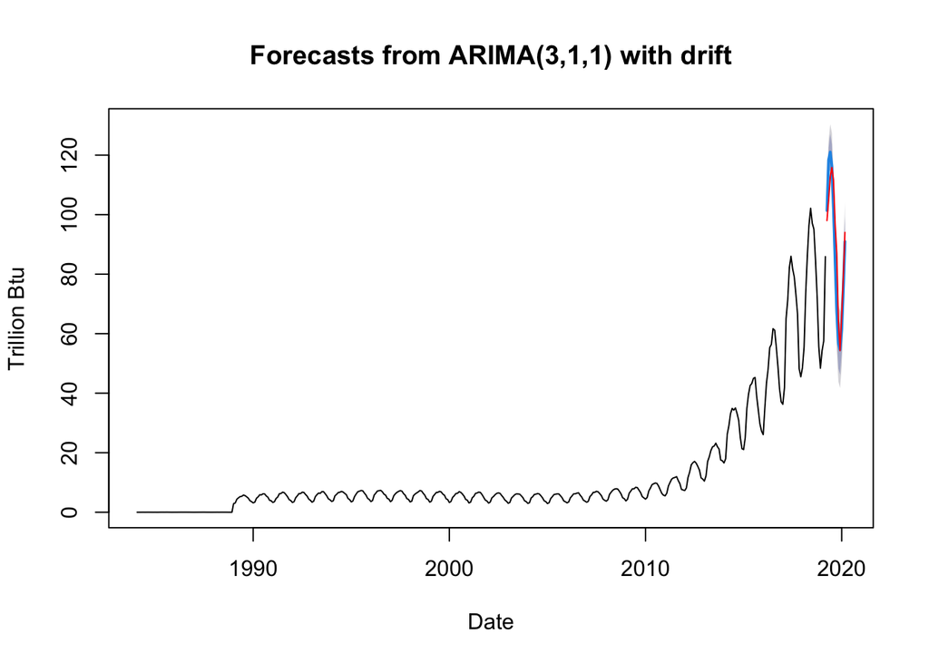

As seen below, the ARIMA model had lower values for all forecast metrics examined. I will try several other forecasting methods to see which one has the best performance on this data.

```r
arima_metrics <- get_metrics(best_arima_result$data_eval)
kable(as.data.frame(arima_metrics) %>% select_all, caption = "ARIMA Forecast Metrics") %>% kable_styling(full_width = F, bootstrap_options = c("condensed"))
```

ARIMA Forecast Metrics

| MAPE | RMSE | MAE | MASE | Bias |
| --- | --- | --- | --- | --- |
| 8.11% | 9.31 | 0.68 | 7.38 | 2.98 |

Next, I will try adding Fourier components to the ARIMA forecast:

```r
best_fourier_result <- best_fourier(ts_train, ts_test)
```

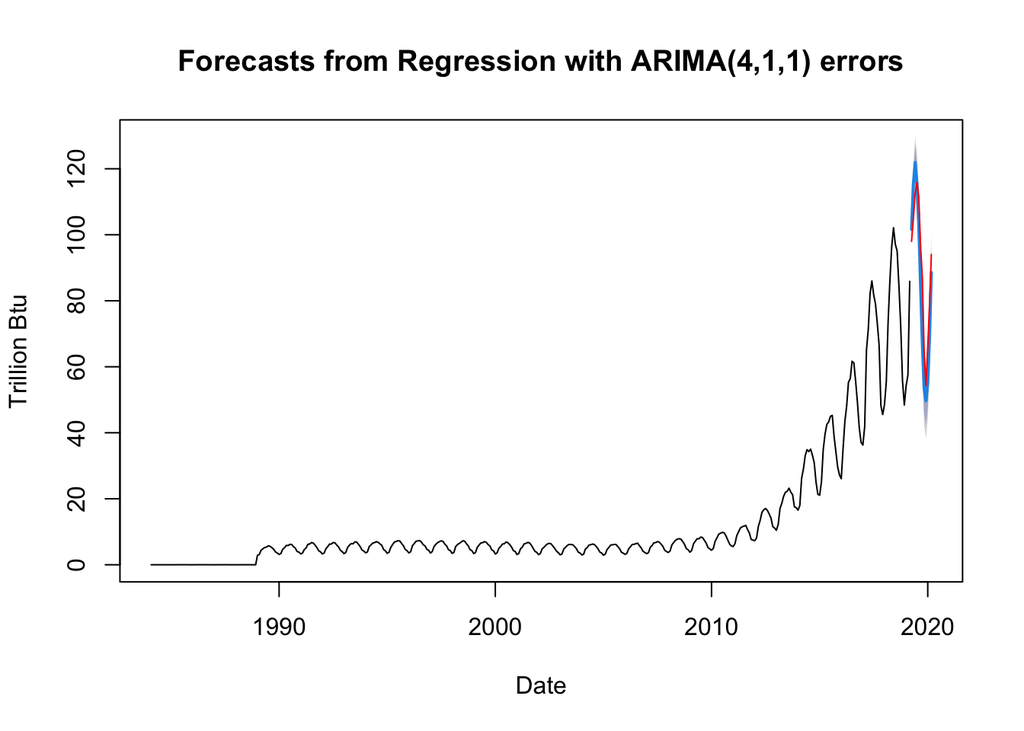

The Fourier forecast with 4 auto-regressive terms, 1 nonseasonal difference, and 1 moving-average term had the lowest aicc value. The metrics for this forecast are shown below:

```r
fourier_metrics <- get_metrics(best_fourier_result$data_eval)
kable(as.data.frame(fourier_metrics) %>% select_all, caption = "ARIMA/Fourier Forecast Metrics") %>% kable_styling(full_width = F, bootstrap_options = c("condensed"))
```

ARIMA/Fourier Forecast Metrics

| MAPE | RMSE | MAE | MASE | Bias |
| --- | --- | --- | --- | --- |
| 10.48% | 10.09 | 0.82 | 8.86 | 4.92 |

Now, I will generate an ETS model:

```r
best_ets_result <- ets_model(ts_train, ts_test)
```

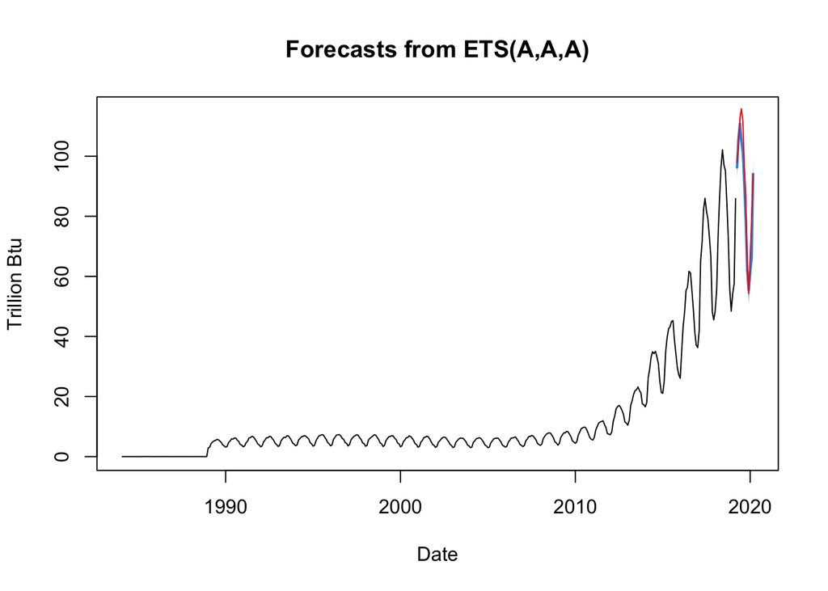

The ETS metrics are shown below:

```r
ets_metrics <- get_metrics(best_ets_result$data_eval)
kable(as.data.frame(ets_metrics) %>% select_all, caption = "ETS Forecast Metrics") %>% kable_styling(full_width = F, bootstrap_options = c("condensed"))
```

ETS Forecast Metrics

| MAPE | RMSE | MAE | MASE | Bias |
| --- | --- | --- | --- | --- |
| 5.73% | 6.72 | 0.48 | 5.17 | 4.73 |

Finally, I will print out the summary statistics to compare the naive, ARIMA, Fourier, and ETS forecast models:

```r
summary_stats <- metrics_summary(c('naive_metrics', 'arima_metrics', 'fourier_metrics', 'ets_metrics'))
kable(as.data.frame(summary_stats) %>% select_all, caption = "Summary Forecast Metrics") %>% kable_styling(full_width = F, bootstrap_options = c("condensed", "striped")) %>%
  row_spec(which(summary_stats$RMSE == min(summary_stats$RMSE)),
           bold = T, color = "white", background = "green") %>%
  column_spec(1, bold=T)
```

Summary Forecast Metrics

| Model | MAPE | RMSE | MAE | MASE | Bias |
| --- | --- | --- | --- | --- | --- |
| naive | 21.21% | 20.13 | 1.64 | 17.77 | 4.47 |
| arima | 8.11% | 9.31 | 0.68 | 7.38 | 2.98 |
| fourier | 10.48% | 10.09 | 0.82 | 8.86 | 4.92 |
| ets | 5.73% | 6.72 | 0.48 | 5.17 | 4.73 |

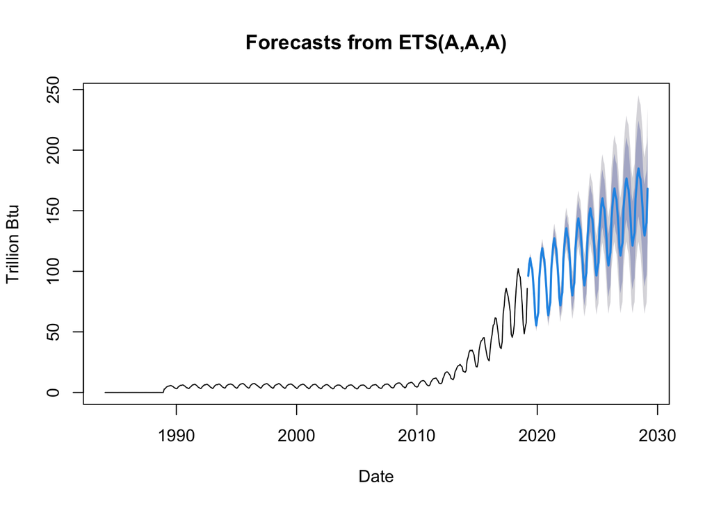

```r
forecast_data <- forecast(best_ets_result$model, level=c(80,95), h= 120)
plot(forecast_data, xlab="Date", ylab="Trillion Btu")
```